# Statistical analysis: Multivalent Antigen Display on Nanoparticles Elicits Diverse and Broad B cell Responses

## 4.2 Competition for epitopes on postF (Fig. 3L)

Competition with three (3) reference mAbs targeting distinct epitopes on postF were analyzed. Each of the three groups was compared against each other at each of two time points using a two-tailed Wilcoxon rank sum test (a.k.a. Mann-Whitney U test or a non-parametric t-test). This means a total of six (6) comparisons were made for each of the reference mAbs. Thus, a total of 18 comparisons were made. To correct for these multiple comparisons, the false discovery rate correction by Benjamini & Hochberg (1995) was applied (alpha = 0.05). Also, the p-values and adjusted p-values for each comparison are listed in the table that follows.

```r
# The comparison of groups by time point is done for each antigenic site on postF (i.e., sites I, II, IV)
my_comparisons_postF <- c(my_comparisons_1, my_comparisons_2, my_comparisons_4)

# The two-tailed Wilcoxon rank sum test with an FDR correction is run for the 18 comparisons specified earlier
stat.test <- data_comp_longer_noPostF %>%
  filter(conformation == "PostF") %>%
  wilcox_test(formula = ELISA_competition ~ timepoint_group_epitope,
              paired = FALSE,
              p.adjust.method = "fdr",
              comparisons = my_comparisons_postF)

# The statistical analyses are printed as a table (shown below)
stat.test %>%
  select(-c(.y.)) %>%
  kable %>%
  kable_styling("striped") %>%
 scroll_box(height = "200px")
```

| group1 | group2 | n1 | n2 | statistic | p | p.adj | p.adj.signif |
| --- | --- | --- | --- | --- | --- | --- | --- |
| B1_1-mer_I | B1_20-mer_I | 4 | 5 | 0.0 | 0.020 | 0.088 | ns |
| B1_1-mer_I | B1_10-mer_I | 4 | 5 | 0.0 | 0.020 | 0.088 | ns |
| B1_10-mer_I | B1_20-mer_I | 5 | 5 | 3.0 | 0.056 | 0.143 | ns |
| B2_1-mer_I | B2_20-mer_I | 4 | 5 | 0.0 | 0.016 | 0.088 | ns |
| B2_1-mer_I | B2_10-mer_I | 4 | 5 | 5.0 | 0.286 | 0.372 | ns |
| B2_10-mer_I | B2_20-mer_I | 5 | 5 | 7.0 | 0.310 | 0.372 | ns |
| B1_1-mer_II | B1_20-mer_II | 4 | 5 | 3.5 | 0.125 | 0.281 | ns |
| B1_1-mer_II | B1_10-mer_II | 4 | 5 | 8.5 | 0.771 | 0.771 | ns |
| B1_10-mer_II | B1_20-mer_II | 5 | 5 | 6.5 | 0.236 | 0.354 | ns |
| B2_1-mer_II | B2_20-mer_II | 4 | 5 | 1.0 | 0.032 | 0.095 | ns |
| B2_1-mer_II | B2_10-mer_II | 4 | 5 | 4.0 | 0.190 | 0.354 | ns |
| B2_10-mer_II | B2_20-mer_II | 5 | 5 | 8.0 | 0.421 | 0.446 | ns |
| B1_1-mer_IV | B1_20-mer_IV | 4 | 5 | 1.0 | 0.032 | 0.095 | ns |
| B1_1-mer_IV | B1_10-mer_IV | 4 | 5 | 4.5 | 0.219 | 0.354 | ns |
| B1_10-mer_IV | B1_20-mer_IV | 5 | 5 | 6.0 | 0.222 | 0.354 | ns |
| B2_1-mer_IV | B2_20-mer_IV | 4 | 5 | 0.0 | 0.016 | 0.088 | ns |
| B2_1-mer_IV | B2_10-mer_IV | 4 | 5 | 6.0 | 0.413 | 0.446 | ns |
| B2_10-mer_IV | B2_20-mer_IV | 5 | 5 | 7.0 | 0.310 | 0.372 | ns |

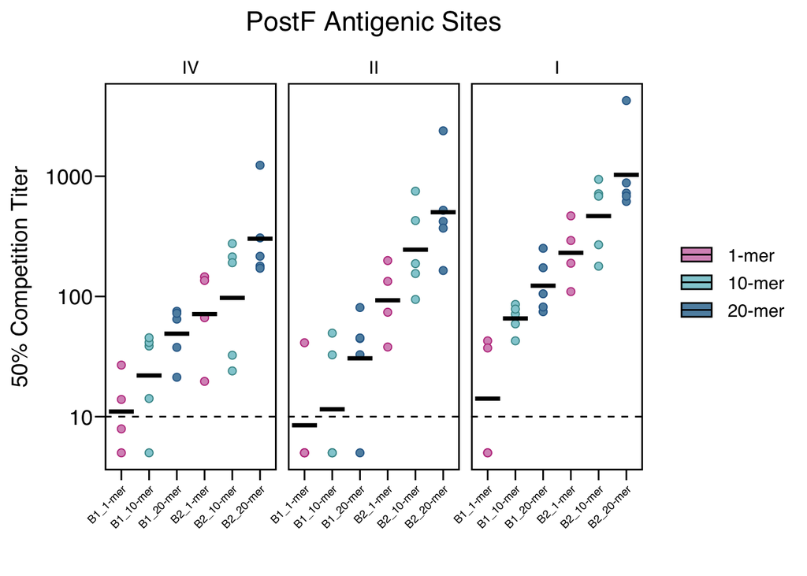

```r
# The data is plotted as a dot plot with corresponding adjusted p-values reaching significance (adj. p < 0.05)
data_comp_longer_noPostF %>%
  filter(conformation == "PostF") %>%
  ggplot(aes(x = timepoint_group,
            y = ELISA_competition,
            color = group,
            fill = group)) +
  geom_point(size = 2, shape = 21) +
  scale_fill_manual(values = fill_col_values) +
  scale_color_manual(values = color_values) +
  ggprism::theme_prism(base_fontface = "plain", border = TRUE, base_line_size = .5) +
  scale_y_log10() +
  stat_summary(fun.y = mean,
               geom = "crossbar",
               color = "black") +
  geom_hline(yintercept = 10, linetype = "dashed") +
  labs(title = "PostF Antigenic Sites", y = "50% Competition Titer", x = "") +
  theme(axis.ticks = element_line(size = .5),
        legend.background = element_blank(),
        axis.text.x = element_text(angle = 45, vjust = 1, hjust=1, size = 7)) +
  facet_wrap(~epitopes, nrow = 1)
```

# 5 Memory B cell profiling

## 5.1 Count unique IGHV-IGHJ pairs (Fig. 5J)

The diversity of responding B cells was here assessed by gene usage and counting of unique IGHV-IGHJ pairs. The two groups were compared against each other at each of two time points for three different specificities: Total F, preF, or preF/postF (DP). For this, a two-tailed Wilcoxon rank sum test (a.k.a. Mann-Whitney U test) was employed. This means a total of six (6) comparisons were made. To correct for these multiple comparisons, the false discovery rate correction by Benjamini & Hochberg (1995) was applied (alpha = 0.05). Also, the p-values and adjusted p-values for each comparison are listed in the table that follows.

```r
# The two vaccine groups are compared by specificity at each sequenced timepoint
my_comparisons <- list(c("Total_B1_20-mer", "Total_B1_1-mer"),
                       c("Total_B2_20-mer", "Total_B2_1-mer"),
                       c("PreF_B1_20-mer", "PreF_B1_1-mer"),
                       c("PreF_B2_20-mer", "PreF_B2_1-mer"),
                       c("DP_B1_20-mer", "DP_B1_1-mer"),
                       c("DP_B2_20-mer", "DP_B2_1-mer"))

# The two-tailed Wilcoxon rank sum test with an FDR correction is run for the 6 comparisons specified earlier
stat.test <- rds_summary_noPV %>%
              wilcox_test(formula = unique_v_j ~ Group_specificity,
                          comparisons = my_comparisons,
                          p.adjust.method = "fdr",
                          paired = FALSE) %>%
  add_xy_position()

# The statistical analyses are printed as a table (shown below)
stat.test %>%
  select(-c(.y., y.position,    groups, xmin,   xmax)) %>%
  kable %>%
  kable_styling("striped") %>%
 scroll_box(height = "200px")
```

group1

group2

n1

n2

statistic

p

p.adj

p.adj.signif

Total_B1_20-mer

Total_B1_1-mer

5

4

14

0.413

0.496

ns

Total_B2_20-mer

Total_B2_1-mer

5

4

11

0.901

0.901

ns

PreF_B1_20-mer

PreF_B1_1-mer

5

4

4

0.176

0.264

ns

PreF_B2_20-mer

PreF_B2_1-mer

5

4

0

0.016

0.048

DP_B1_20-mer

DP_B1_1-mer

5

4

20

0.016

0.048

DP_B2_20-mer

DP_B2_1-mer

5

4

18

0.064

0.127

ns

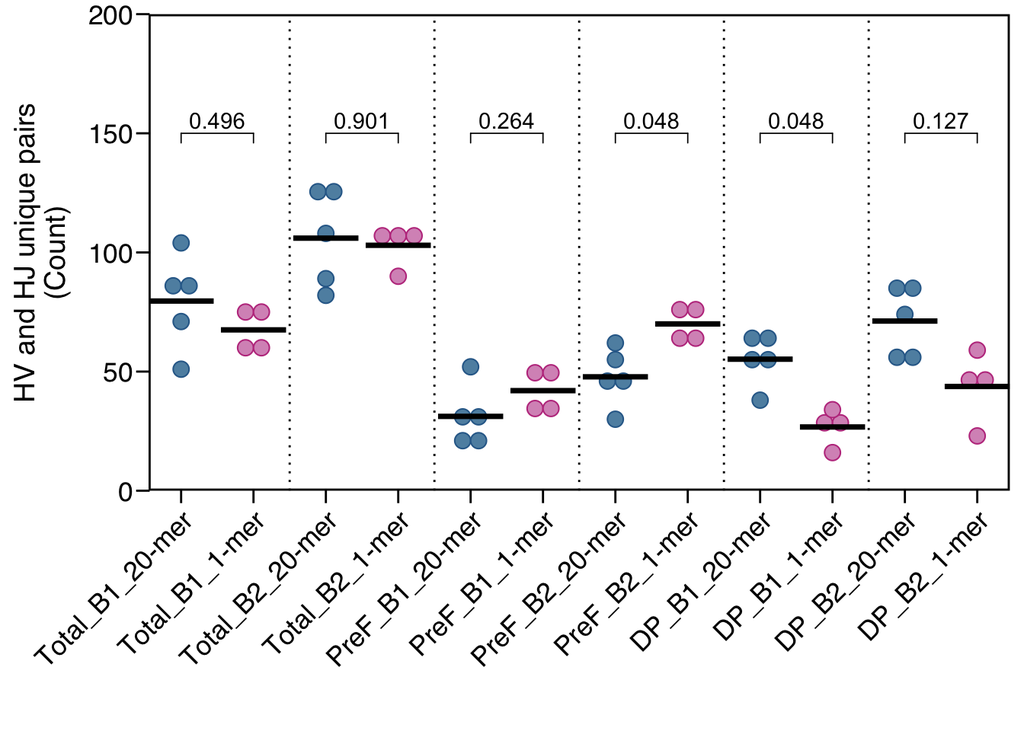

```r
# The data is plotted as a dot plot with corresponding adjusted p-values
rds_summary_noPV %>%
  ggpubr::ggdotplot(x = "Group_specificity", y = "unique_v_j",
                    fill = "Group",
                    color = "Group",
                    group = "Group_specificity",
                    legend = "none", size = 1) +
  geom_vline(xintercept = seq(2.5,12,2), linetype = "dotted") +
  scale_y_continuous(expand = c(0, 0), limits = c(0, 200)) +
  scale_x_discrete(expand = c(0, 0)) +
  scale_fill_manual(values = fill_col_values) +
  scale_color_manual(values = color_values) +
  labs(y = "HV and HJ unique pairs\n(Count)", x = "") +
  stat_summary(fun.y = mean,
               geom = "crossbar") +
  stat_pvalue_manual(stat.test, label = "p.adj", y.position = 150) +
  ggprism::theme_prism(base_fontface = "plain", border = T, base_line_size = .5, axis_text_angle = 45) +
  theme(axis.ticks = element_line(size = .5),
        legend.position = "none")
```

## 5.2 Clonotype richness Chao1 (Fig. 5K)

The species richness (Chao1) used in this section was calculated using the vegan R package. The samples were first subsampled 100 times for each animal at each timepoint and specificity and then the species richness was estimated. The means of the 100x replicates were used for plotting. As before, the two groups were compared against each other at each of two time points for three different specificities: Total F, preF, or preF/postF (DP). For this, a two-tailed Wilcoxon rank sum test (a.k.a. Mann-Whitney U test) was employed. This means a total of six (6) comparisons were made. To correct for these multiple comparisons, the false discovery rate correction by Benjamini & Hochberg (1995) was applied (alpha = 0.05). Also, the p-values and adjusted p-values for each comparison are listed in the table that follows.

```r
stat.test <- chao_results_df %>%
              wilcox_test(formula = value ~ Group_specificity,
                          comparisons = my_comparisons,
                          p.adjust.method = "fdr",
                          paired = FALSE) %>%
  add_xy_position()

stat.test %>%
  select(-c(.y., y.position,    groups, xmin,   xmax)) %>%
  kable %>%
  kable_styling("striped") %>%
 scroll_box(height = "200px")
```

group1

group2

n1

n2

statistic

p

p.adj

p.adj.signif

Total_B1_20-mer

Total_B1_1-mer

5

4

16

0.190

0.285

ns

Total_B2_20-mer

Total_B2_1-mer

5

4

15

0.286

0.343

ns

PreF_B1_20-mer

PreF_B1_1-mer

5

4

7

0.556

0.556

ns

PreF_B2_20-mer

PreF_B2_1-mer

5

4

2

0.064

0.127

ns

DP_B1_20-mer

DP_B1_1-mer

5

4

20

0.016

0.048

DP_B2_20-mer

DP_B2_1-mer

5

4

20

0.016

0.048

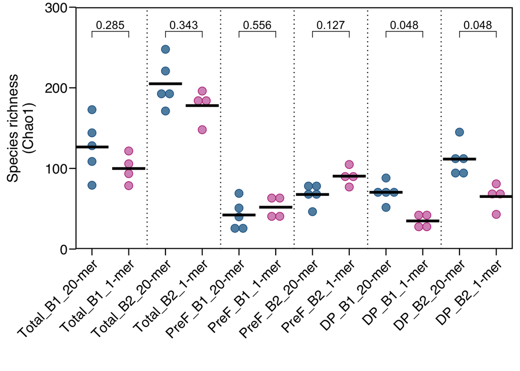

```r
chao_results_df %>%
  ggpubr::ggdotplot(x = "Group_specificity", y = "value",
                    fill = "Group",
                    color = "Group",
                    group = "Group_specificity",
                    legend = "none", size = 1) +
  geom_vline(xintercept = seq(2.5,12,2), linetype = "dotted") +
  scale_y_continuous(expand = c(0, 0), limits = c(0, 300)) +
  scale_x_discrete(expand = c(0, 0)) +
  scale_fill_manual(values = fill_col_values) +
  scale_color_manual(values = color_values) +
  labs(y = "Species richness\n(Chao1)", x = "") +
  stat_summary(fun.y = mean,
               geom = "crossbar") +
  stat_pvalue_manual(stat.test, label = "p.adj", y.position = 270) +
  ggprism::theme_prism(base_fontface = "plain", border = T, base_line_size = .5, axis_text_angle = 45) +
  theme(axis.ticks = element_line(size = .5),
        legend.position = "none")
```

## 5.3 Clonotype richness – Recon (Fig. 5L)

The species richness (Recon) used in this section was calculated using Recon (v2.5) (Kaplinsky & Arnaout, Nat Commmun, 2016) according to default parameters. As before, the two groups were compared against each other at each of two time points for three different specificities: Total F, preF, or preF/postF (DP). For this, a two-tailed Wilcoxon rank sum test (a.k.a. Mann-Whitney U test) was employed. This means a total of six (6) comparisons were made. To correct for these multiple comparisons, the false discovery rate correction by Benjamini & Hochberg (1995) was applied (alpha = 0.05). Also, the p-values and adjusted p-values for each comparison are listed in the table that follows.

```r
## The output from Recon was used to perform the statistics, here the data is just processed to have the correct rows and nomenclatures.
recon_res <- read.table("../data/diversity_index/recon/rsv_output_diversity_table.txt", header = TRUE) %>%
  filter(Timepoint != "PV", Timepoint != "Single-cell", Specificity != "PostF") %>%
  mutate(Group = plyr::mapvalues(
      ID, c(
        "E11", "E16", "E17", "E23", "E24",
        "E12", "E14", "E18", "E21"
      ),
      c(
        "20-mer", "20-mer", "20-mer", "20-mer", "20-mer",
        "1-mer", "1-mer", "1-mer", "1-mer"
      )
    ),
   Group_specificity = paste(Specificity, Timepoint, Group, sep = "_")) %>%
  mutate(Group_specificity = factor(Group_specificity, levels = c("Total_B1_20-mer", "Total_B1_1-mer", "Total_B2_20-mer", "Total_B2_1-mer", "PreF_B1_20-mer", "PreF_B1_1-mer", "PreF_B2_20-mer", "PreF_B2_1-mer", "DP_B1_20-mer", "DP_B1_1-mer", "DP_B2_20-mer", "DP_B2_1-mer"))) %>%
  ungroup()

write.csv(recon_res, paste0("../", result.dir, "recon_results_plot_values.csv"), row.names = FALSE)

# The two-tailed Wilcoxon rank sum test with an FDR correction is run for the 6 comparisons specified earlier
stat.test <- recon_res %>%
              wilcox_test(formula = est_0.0D ~ Group_specificity,
                          comparisons = my_comparisons,
                          p.adjust.method = "fdr",
                          paired = FALSE) %>%
  add_xy_position()

# The statistical analyses are printed as a table (shown below)
stat.test %>%
  select(-c(.y., y.position,    groups, xmin,   xmax)) %>%
  kable %>%
  kable_styling("striped") %>%
 scroll_box(height = "200px")
```

group1

group2

n1

n2

statistic

p

p.adj

p.adj.signif

Total_B1_20-mer

Total_B1_1-mer

5

4

16

0.190

0.228

ns

Total_B2_20-mer

Total_B2_1-mer

5

4

16

0.190

0.228

ns

PreF_B1_20-mer

PreF_B1_1-mer

5

4

7

0.556

0.556

ns

PreF_B2_20-mer

PreF_B2_1-mer

5

4

2

0.064

0.127

ns

DP_B1_20-mer

DP_B1_1-mer

5

4

20

0.016

0.048

DP_B2_20-mer

DP_B2_1-mer

5

4

20

0.016

0.048

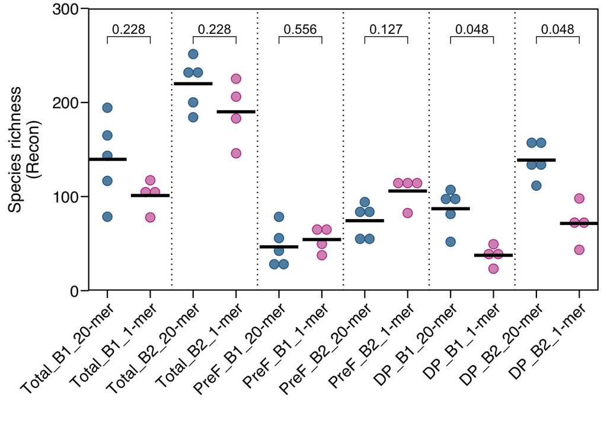

```r
# The data is plotted as a dot plot with corresponding adjusted p-values
recon_res %>%
  ggpubr::ggdotplot(x = "Group_specificity", y = "est_0.0D",
                    fill = "Group",
                    color = "Group",
                    group = "Group_specificity",
                    legend = "none", size = 1) +
  geom_vline(xintercept = seq(2.5,12,2), linetype = "dotted") +
  scale_y_continuous(expand = c(0, 0), limits = c(0, 300)) +
  scale_x_discrete(expand = c(0, 0)) +
  scale_fill_manual(values = fill_col_values) +
  scale_color_manual(values = color_values) +
  labs(y = "Species richness\n(Recon)", x = "") +
  stat_summary(fun.y = mean,
               geom = "crossbar") +
  stat_pvalue_manual(stat.test, label = "p.adj", y.position = 270) +
  ggprism::theme_prism(base_fontface = "plain", border = T, base_line_size = .5, axis_text_angle = 45) +
  theme(axis.ticks = element_line(size = .5),
        legend.position = "none")
```

## 5.4 Somatic hypermutation (SHM) comparisons

### 5.4.1 SHM of all sequences (Fig. S4K)

Here, the SHM for all antigen-specific sequences is combined by group. The two groups were compared against each other at each of two time points for three different specificities: Total F, preF, or preF/postF (DP). For this comparison, a normal distribution can be assumed due to the large number of sequences. Thus, a two-tailed Student’s t-test was employed. This means a total of six (6) comparisons were made. To correct for these multiple comparisons, the false discovery rate correction by Benjamini & Hochberg (1995) was applied (alpha = 0.05). Also, the p-values and adjusted p-values for each comparison are listed in the table that follows. Due to the very large sample size, small differences can lead to extremely small p-values. Therefore, we have also calculated the Cohen’s d (1988) to estimate the effect size between the two group means. The magnitude of the effect size was small for most comparisons, suggesting that these highly statistically significant but small differences may not have biological significance.

```r
rds_indiv_total <- rds_merge %>%
  mutate(specificity_group = "Total")

rds_indiv_plot <- rbind(rds_merge, rds_indiv_total)

rds_indiv_plot <- rds_indiv_plot %>%
  filter(specificity_group != "PostF") %>%
  mutate(Group_specificity = paste(specificity_group, Timepoint, Group, sep = "_")) %>%
  mutate(Group_specificity = factor(Group_specificity, levels = c("Total_B1_20-mer", "Total_B1_1-mer", "Total_B2_20-mer", "Total_B2_1-mer", "PreF_B1_20-mer", "PreF_B1_1-mer", "PreF_B2_20-mer", "PreF_B2_1-mer", "DP_B1_20-mer", "DP_B1_1-mer", "DP_B2_20-mer", "DP_B2_1-mer"))) %>% ungroup() %>% drop_na(Group_specificity)

# Save the dataset from above used for statistics
write.csv(rds_indiv_plot %>% select(ID, Timepoint, Group_specificity, V_errors),
          paste0("../", result.dir, "antigen_specific_total_shm.csv"),row.names = FALSE)


# The two-tailed Student's t-test with an FDR correction is run for the 6 comparisons specified earlier
stat.test <- rds_indiv_plot %>%
              t_test(formula = V_errors ~ Group_specificity,
                          comparisons = my_comparisons,
                          p.adjust.method = "fdr",
                          paired = FALSE) %>%
  add_xy_position() %>%
  mutate(p.adj = ifelse(p.adj<= 0.00001, "0.0000",p.adj))

# The effect size was calculated using Cohen's method
stat.effectsize <- rds_indiv_plot %>%
              cohens_d(formula = V_errors ~ Group_specificity,
                          comparisons = my_comparisons,
                          paired = FALSE)
# Staltistical results are merged in a single object
stats <- left_join(stat.test, stat.effectsize, by = c("group1","group2", ".y.", "n1", "n2")) %>%
  mutate(effsize = paste0("d=",round(effsize, 2)))

# The statistical analyses, including effect size, are printed as a table (shown below)
stats %>%
  select(-c(.y., y.position,    groups, xmin,   xmax)) %>%
  kable %>%
  kable_styling("striped") %>%
 scroll_box(height = "200px")
```

| group1 | group2 | n1 | n2 | statistic | df | p | p.adj | p.adj.signif | effsize | magnitude |
| --- | --- | --- | --- | --- | --- | --- | --- | --- | --- | --- |
| Total_B1_20-mer | Total_B1_1-mer | 71438 | 41890 | -87.28487 | 69428.50 | 0 | 0.0000 | **** | d=-0.56 | moderate |
| Total_B2_20-mer | Total_B2_1-mer | 141383 | 92712 | -109.75370 | 156228.86 | 0 | 0.0000 | **** | d=-0.48 | small |
| PreF_B1_20-mer | PreF_B1_1-mer | 20774 | 21126 | -20.99717 | 40137.01 | 0 | 0.0000 | **** | d=-0.2 | small |
| PreF_B2_20-mer | PreF_B2_1-mer | 48561 | 47362 | -60.25144 | 84908.63 | 0 | 0.0000 | **** | d=-0.39 | small |
| DP_B1_20-mer | DP_B1_1-mer | 38256 | 8444 | -28.13522 | 10542.46 | 0 | 0.0000 | **** | d=-0.37 | small |
| DP_B2_20-mer | DP_B2_1-mer | 82239 | 33204 | -54.93375 | 50210.27 | 0 | 0.0000 | **** | d=-0.38 | small |

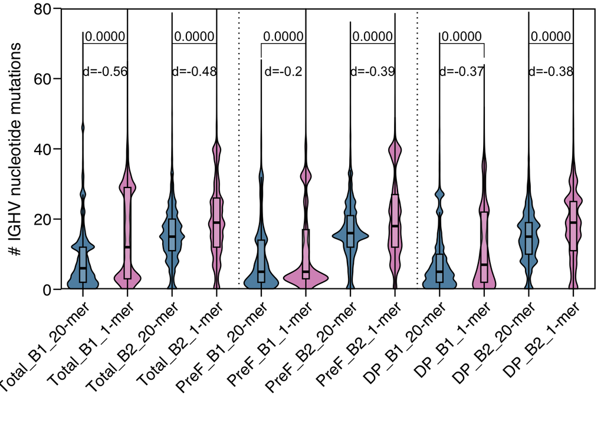

```r
# The SHM mean, standard deviation, n size, and the confidence interval per group was calculated and saved to summarise the dataset used and provided within this repository
counts <- rds_indiv_plot %>% group_by(Group, specificity_group) %>%
  rename(shm = V_errors) %>%
  summarise(mean.shm = mean(shm, na.rm = TRUE),
            sd.shm = sd(shm, na.rm = TRUE),
            n.shm = n()) %>%
  mutate(se.shm = sd.shm / sqrt(n.shm),
         lower.ci.shm = mean.shm - qt(1 - (0.05 / 2), n.shm - 1) * se.shm,
         upper.ci.shm = mean.shm + qt(1 - (0.05 / 2), n.shm - 1) * se.shm)

write.csv(counts,
          paste0("../", result.dir, "antigen_specific_total_shm_stats.csv"),row.names = FALSE)

# The data is plotted as a dot plot with corresponding adjusted p-values and Cohen's d effect size
rds_indiv_plot %>%
  ggpubr::ggviolin(x = "Group_specificity", y = "V_errors", fill = "Group_specificity", group = "Group_specificity",
                    legend = "none") +
  geom_boxplot(outlier.shape = NA, width = 0.15, color = "black", alpha = 0.2)+
  geom_vline(xintercept = c(4.5, 8.5), linetype = "dotted") +
  scale_y_continuous(expand = c(0, 0), limits = c(0, 80)) +
  scale_shape_manual(values=NA)+
  scale_x_discrete(expand = c(0, 0)) +
  scale_fill_manual(values = rep(c("#5F90B0", "#D896C1"), 6)) +
  labs(y = "# IGHV nucleotide mutations",  x= "") +
  stat_pvalue_manual(stats, label = "p.adj", y.position = 70) +
  stat_pvalue_manual(stats, label = "effsize", y.position = 60, remove.bracket = TRUE) +
  ggprism::theme_prism(base_fontface = "plain", border = T, base_line_size = .5, axis_text_angle = 45) +
  theme(axis.ticks = element_line(size = .5),
        legend.position = "none")
```

### 5.4.2 Mean SHM per animal (Fig. S4K)

Here the SHM data is summarized per animal, so each dot represents the average SHM of all the antigen-specific sequences for each animal. As before, the two groups were compared against each other at each of two time points for three different specificities: Total F, preF, or preF/postF (DP). For this, a two-tailed Wilcoxon rank sum test (a.k.a. Mann-Whitney U test) was employed. This means a total of six (6) comparisons were made. To correct for these multiple comparisons, the false discovery rate correction by Benjamini & Hochberg (1995) was applied (alpha = 0.05). Also, the p-values and adjusted p-values for each comparison are listed in the table that follows.

```r
# The SHM arithmetic mean was calculated per animal and is provided within this repository
rds_indiv_plot_summ <- rds_indiv_plot %>%
  filter(Group_specificity != "PostF") %>%
  group_by(ID, Group_specificity) %>%
  summarise(avg_V_errors = mean(V_errors, na.rm = TRUE)) %>%
  ungroup() %>%
  tidyr::drop_na()

write.csv(rds_indiv_plot_summ,
          paste0("../", result.dir, "antigen_specific_mean_shm_per_animal.csv"),row.names = FALSE)

# The two-tailed Wilcoxon rank sum test with an FDR correction is run for the 6 comparisons specified earlier
stat.test <- rds_indiv_plot_summ %>%
              wilcox_test(formula = avg_V_errors ~ Group_specificity,
                          comparisons = my_comparisons,
                          p.adjust.method = "fdr",
                          paired = FALSE) %>%
  add_xy_position()

# The statistical analyses are printed as a table (shown below)
stat.test %>%
  select(-c(.y., y.position,    groups, xmin,   xmax)) %>%
  kable %>%
  kable_styling("striped") %>%
 scroll_box(height = "200px")
```

| group1 | group2 | n1 | n2 | statistic | p | p.adj | p.adj.signif |
| --- | --- | --- | --- | --- | --- | --- | --- |
| Total_B1_20-mer | Total_B1_1-mer | 5 | 4 | 5 | 0.286 | 0.826 | ns |
| Total_B2_20-mer | Total_B2_1-mer | 5 | 4 | 6 | 0.413 | 0.826 | ns |
| PreF_B1_20-mer | PreF_B1_1-mer | 5 | 4 | 8 | 0.730 | 0.876 | ns |
| PreF_B2_20-mer | PreF_B2_1-mer | 5 | 4 | 8 | 0.730 | 0.876 | ns |
| DP_B1_20-mer | DP_B1_1-mer | 5 | 4 | 4 | 0.190 | 0.826 | ns |
| DP_B2_20-mer | DP_B2_1-mer | 5 | 4 | 10 | 1.000 | 1.000 | ns |

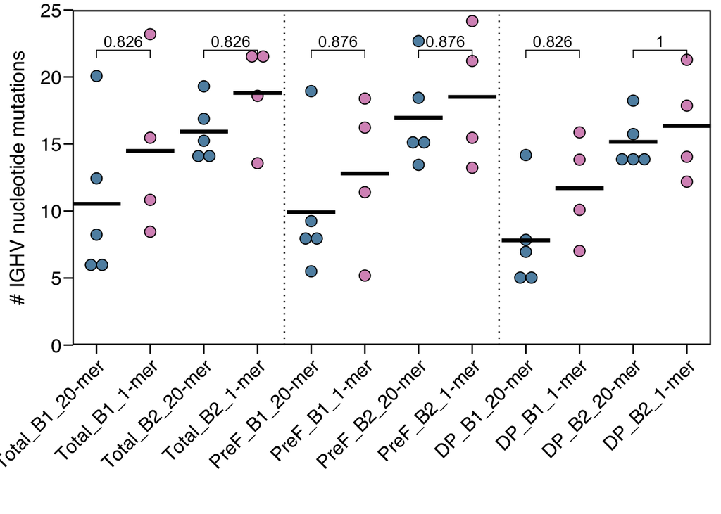

```r
# The data is plotted as a dot plot with corresponding adjusted p-values
rds_indiv_plot_summ %>%
  ggpubr::ggdotplot(x = "Group_specificity", y = "avg_V_errors", fill = "Group_specificity", group = "Group_specificity",
                    legend = "none") +
  geom_vline(xintercept = c(4.5, 8.5), linetype = "dotted") +
  scale_y_continuous(expand = c(0, 0), limits = c(0, 25)) +
  scale_shape_manual(values=NA)+
  scale_x_discrete(expand = c(0, 0)) +
  scale_fill_manual(values = rep(c("#5F90B0", "#D896C1"), 6)) +
  stat_summary(fun.y = mean,
               geom = "crossbar") +
  labs(y = "# IGHV nucleotide mutations",  x= "") +
  stat_pvalue_manual(stat.test, label = "p.adj", y.position = 22) +
  ggprism::theme_prism(base_fontface = "plain", border = T, base_line_size = .5, axis_text_angle = 45) +
  theme(axis.ticks = element_line(size = .5),
        legend.position = "none")
```